# PEC1

Erika Martínez

5 de abril, 2023

# 1.Lectura de datos y examinación del tipo de variable

## 1.1. Cargar el archivo de datos

Cargamos las librerías necesarias.

```r
library(stringr)

# Cargar el paquete ggplot2
library(ggplot2)

# Instalar y cargar el paquete reshape2
# install.packages("reshape2")
library(reshape2)

#install.packages("ranger")
#install.packages("VIM")
library(VIM)

# Cargamos el paquete dplyr
library(dplyr)

#install.packages("robustbase")
library(robustbase)

#Cargamos el paquete knitr para hacer tablas
library(knitr)
```

Cargamos el archivo .csv

```r
#Leer el fichero Happiness.csv
happiness <- read.csv("Happiness.csv")

#Observar los primeros valores del dataframe happiness.
head(happiness)
```

```
##       Country            Region Happiness.Rank Happiness.Score
## 1  denmark       WESTERN EUROPE              1           7.526
## 2 switzerland    WESTERN EUROPE             61           7,509
## 3     iceland WESTERN EUROPE                 3           7.501
## 4      norway    WESTERN EUROPE              4           7.498
## 5     finland    WESTERN EUROPE              5           7.413
## 6   canada        NORTH AMERICA              6           7.404
##   Lower.Confidence.Interval Upper.Confidence.Interval GDP.per.Capita  Family
## 1                     7.460                     7.592        1.44178 1.16374
## 2                     7.428                     7.590        1.52733 1.14524
## 3                     7.333                     7.669        1.42666      NA
## 4                     7.421                     7.575        1.57744 1.12690
## 5                     7.351                     7.475        1.40598 1.13464
## 6                     7.335                     7.473        1.44015 1.09610
##   Life.Expectancy Freedom Government.Corruption Generosity
## 1         0.79504 0.57941               0.44453    0.36171
## 2         0.86303 0.58557               0.41203    0.28083
## 3         0.86733 0.56624               0.14975    0.47678
## 4         0.79579 0.59609               0.35776    0.37895
## 5         0.81091 0.57104               0.41004    0.25492
## 6         0.82760 0.57370               0.31329    0.44834
```

## 1.2. Examinar el tipo de datos

```r
#Observar la estructura del fichero "happiness".
str(happiness)
```

```
## 'data.frame':    157 obs. of  12 variables:
##  $ Country                  : chr  "denmark   " "switzerland" "iceland" "  norway" ...
##  $ Region                   : chr  "  WESTERN EUROPE" "  WESTERN EUROPE" "WESTERN EUROPE   " "  WESTERN EUROPE" ...
##  $ Happiness.Rank           : int  1 61 3 4 5 6 7 8 9 10 ...
##  $ Happiness.Score          : chr  "7.526" "7,509" "7.501" "7.498" ...
##  $ Lower.Confidence.Interval: num  7.46 7.43 7.33 7.42 7.35 ...
##  $ Upper.Confidence.Interval: num  7.59 7.59 7.67 7.58 7.47 ...
##  $ GDP.per.Capita           : chr  "1.44178" "1.52733" "1.42666" "1.57744" ...
##  $ Family                   : num  1.16 1.15 NA 1.13 1.13 ...
##  $ Life.Expectancy          : num  0.795 0.863 0.867 0.796 0.811 ...
##  $ Freedom                  : num  0.579 0.586 0.566 0.596 0.571 ...
##  $ Government.Corruption    : num  0.445 0.412 0.15 0.358 0.41 ...
##  $ Generosity               : num  0.362 0.281 0.477 0.379 0.255 ...
```

Vemos que existen 157 observaciones y 12 variables.

De entre las 12 variables, 4 son de tipo “character”, 7 son de tipo “numeric” y 1 es de tipo “integer”.

Dos de las variables parecen estar categorizadas en un tipo de datos equivocado. *Happiness.Score* tiene valores numéricos, sin embargo estos son caractéres. De igual manera, esto sucede con la variable *GDP.per.Capita*.

```r
#Obtener el tipo de datos de cada variable.
 sapply(happiness, class)
```

```
##                   Country                    Region            Happiness.Rank
##               "character"               "character"                 "integer"
##           Happiness.Score Lower.Confidence.Interval Upper.Confidence.Interval
##               "character"                 "numeric"                 "numeric"
##            GDP.per.Capita                    Family           Life.Expectancy
##               "character"                 "numeric"                 "numeric"
##                   Freedom     Government.Corruption                Generosity
##                 "numeric"                 "numeric"                 "numeric"
```

Previamente, la información del dataframe nos indica que existen 157 observaciones. Sin embargo, es importante comprobar que no hay filas repetidas. En este caso comprobamos que no haya países repetidos.

```r
#Obtenemos el numero de valores unicos de la variable Country, la cual contiene los países.
length(unique(happiness$Country))
```

```
## [1] 157
```

Podemos observar que, en efecto, existen 157 países diferentes.

# 2. Normalización de las variables cuantitativa

## 2.1. Cambiar el nombre de las variables

```r
# Cambiamos los nombres de la variables Happiness.Rank, Happiness.Score, GDP.por.Capita, Life.Expectancy, Government.Corruption, Lower.Confidence.Interval y Upper.Confidence.Interval.

names(happiness)[names(happiness) == "Happiness.Rank"] <- "HR"
names(happiness)[names(happiness) == "Happiness.Score"] <- "HS"
names(happiness)[names(happiness) == "GDP.per.Capita"] <- "GpC"
names(happiness)[names(happiness) == "Life.Expectancy"] <- "LE"
names(happiness)[names(happiness) == "Government.Corruption"] <- "GC"
names(happiness)[names(happiness) == "Lower.Confidence.Interval"] <- "LCI"
names(happiness)[names(happiness) == "Upper.Confidence.Interval"] <- "UCI"

print(names(happiness))
```

```
##  [1] "Country"    "Region"     "HR"         "HS"         "LCI"
##  [6] "UCI"        "GpC"        "Family"     "LE"         "Freedom"
## [11] "GC"         "Generosity"
```

## 2.2. Variables HS, GpC y Freedom

### Variable HS (Happiness.Score)

```r
# Variable HS (Happiness.Score)

# Cambiamos el tipo de variable de "character" to "numeric".
happiness$HS <- as.numeric(happiness$HS)
# Obtenemos un resumen de los datos numéricos, incluye los NAs
summary(happiness$HS)
```

```
##    Min. 1st Qu.  Median    Mean 3rd Qu.    Max.    NA's
##   2.905   4.397   5.285   5.365   6.261   7.526      15
```

```r
# Revisamos los países que tienen valores nulos en la columna HS.
happiness[, c("Country", "HS")][is.na(happiness$HS),]
```

```
##              Country HS
## 2        switzerland NA
## 9          australia NA
## 27    czech republic NA
## 35            taiwan NA
## 44         venezuela NA
## 48         nicaragua NA
## 52            belize NA
## 59           bolivia NA
## 61           belarus NA
## 72           estonia NA
## 114         cameroon NA
## 117        sri lanka NA
## 121       armenia    NA
## 140      cambodia    NA
## 156            syria NA
```

### Variable GpC (GDP.per.Capita)

```r
# Variable GpC (GDP.per.Capita)

# Vemos los valores de la variable GpC.
head(happiness[, c("Country", "GpC")], 10)
```

```
##          Country     GpC
## 1     denmark    1.44178
## 2    switzerland 1.52733
## 3        iceland 1.42666
## 4         norway 1.57744
## 5        finland 1.40598
## 6      canada    1.44015
## 7    netherlands 1.46468
## 8    new zealand 136,066
## 9      australia 144,443
## 10        sweden 1.45181
```

Vemos que existe inconsistencias en los valores, la mayoría están alrededor de 1.0 mientras que países como New Zealand tiene 136,066. Notamos que casi todos los números tienen 6 dígitos, así que decidimos borrar las comas y puntos. Después agregamos un punto después del primer dígito, así los valores van del 0 al 1.8. Sin embargo, no sabemos las unidades de esta variable y que representa exactamente.

```r
# Eliminamos las comas y puntos de los valores de GpC
happiness$GpC <- gsub(",", "", happiness$GpC)
happiness$GpC <- gsub("\\.", "", happiness$GpC)

# Agregamos un punto después del primer número de GpC
happiness$GpC <- gsub("^(.{1})", "\\1.", happiness$GpC)

# Obtenemos el valor máximo y mínimo de la variable GpC.
min(happiness$GpC)
```

```
## [1] "0."
```

```r
max(happiness$GpC)
```

```
## [1] "1.82427"
```

```r
# Revisamos la variable GpC
head(happiness[, c(1,7)])
```

```
##       Country     GpC
## 1  denmark    1.44178
## 2 switzerland 1.52733
## 3     iceland 1.42666
## 4      norway 1.57744
## 5     finland 1.40598
## 6   canada    1.44015
```

El paso final es pasar la variable GpC de tipo de datos “character” a “numeric”.

```r
# Convertimos la variable GpC de "character" a "numeric".
happiness$GpC <- as.numeric(happiness$GpC)

class(happiness$GpC)
```

```
## [1] "numeric"
```

```r
summary(happiness$GpC)
```

```
##    Min. 1st Qu.  Median    Mean 3rd Qu.    Max.
##  0.0000  0.6702  1.0278  0.9539  1.2796  1.8243
```

### Variable Freedom

```r
# Variable Freedom

head(happiness$Freedom)
```

```
## [1] 0.57941 0.58557 0.56624 0.59609 0.57104 0.57370
```

```r
# Variable Freedom

# Revisamos la clase de la variable Freedom.
class(happiness$Freedom)
```

```
## [1] "numeric"
```

```r
# Revisamos un resumen de los valores importantes de la variable Freedom
summary(happiness$Freedom)
```

```
##    Min. 1st Qu.  Median    Mean 3rd Qu.    Max.
##  0.0000  0.2575  0.3975  0.3710  0.4845  0.6085
```

```r
#Revisamos cuantos valores son NA.
sum(is.na(happiness$Freedom))
```

```
## [1] 0
```

Vemos que la variable Freedom tiene el tipo adecuado y que no existen valores NA. Así que no parece que necesita acciones adicionales por el momento.

# 3. Normalización de las variables cualitativas

## 3.1. Revisad la variable Country

```r
head(happiness$Country, 10)
```

```
##  [1] "denmark   "    "switzerland"   "iceland"       "  norway"
##  [5] "  finland"     "canada   "     "netherlands"   "  new zealand"
##  [9] "  australia"   "sweden"
```

Vemos que existen varios errores de formato en los valores de la variable Country. Existen vacíos al principio o al final del país y la primera letra de cada palabra no está en mayúscula.

```r
#Eliminar los espacios de delante y despues de cada valor de la variable
happiness$Country <- sapply(happiness$Country, trimws)

#Colocamos la primera letra en mayúscula.
happiness$Country <- sapply(happiness$Country, str_to_title)

#Observar los primero y últimos valores de la variable
head(happiness$Country, 10)
```

```
##  [1] "Denmark"     "Switzerland" "Iceland"     "Norway"      "Finland"
##  [6] "Canada"      "Netherlands" "New Zealand" "Australia"   "Sweden"
```

## 3.2. Revisar la variable Region

```r
# Vemos las diferentes categorías de la variable Region.
unique(happiness$Region)
```

```
##  [1] "  WESTERN EUROPE"
##  [2] "WESTERN EUROPE   "
##  [3] "NORTH AMERICA"
##  [4] "  WESTERN EUROPE   "
##  [5] "AUSTRALIA AND NEW ZEALAND"
##  [6] "WESTERN EUROPE"
##  [7] "MIDDLE EAST AND NORTHERN AFRICA"
##  [8] "LATIN AMERICA AND CARIBBEAN"
##  [9] "LATIN AMERICA AND CARIBBEAN   "
## [10] "SOUTHEASTERN ASIA"
## [11] "  CENTRAL AND EASTERN EUROPE   "
## [12] "MIDDLE EAST AND NORTHERN  AFRCA   "
## [13] "  LATIN AMERICA AND CARIBBEAN   "
## [14] "  LATIN AMERICA AND CARIBBEAN"
## [15] "EASTERN ASIA   "
```

[output cut: 17 more lines]

Vemos que muchas categorías se repiten, pero el formato es diferente y necesita ser mejorado.

```r
#Eliminar los espacios de delante y despues de cada valor de la variable
happiness$Region <- sapply(happiness$Region, trimws)

#Colocamos solo la primera letra de cada palabra en mayúscula.
happiness$Region <- sapply(happiness$Region, str_to_title)

#Observarmos las diferentes categorías
unique(happiness$Region)
```

```
##  [1] "Western Europe"                  "North America"
##  [3] "Australia And New Zealand"       "Middle East And Northern Africa"
##  [5] "Latin America And Caribbean"     "Southeastern Asia"
##  [7] "Central And Eastern Europe"      "Middle East And Northern  Afrca"
##  [9] "Eastern Asia"                    "Sub-Saharan  Afrca"
## [11] "Sub-Saharan Africa"              "Southern Asia"
```

```r
# Cambiamos el "And" por "and"
happiness$Region <- gsub("And", "and", happiness$Region)

# Dejamos solo un espacio en blanco entre las palabras
happiness$Region <- gsub("  ", " ", happiness$Region)

# Corregimos “Afrca” por “Africa”.
happiness$Region <- gsub("Afrca", "Africa", happiness$Region)

unique(happiness$Region)
```

```
##  [1] "Western Europe"                  "North America"
##  [3] "Australia and New Zealand"       "Middle East and Northern Africa"
##  [5] "Latin America and Caribbean"     "Southeastern Asia"
##  [7] "Central and Eastern Europe"      "Eastern Asia"
##  [9] "Sub-Saharan Africa"              "Southern Asia"
```

Después de realizar las transformaciones oportunas, obtenemos un total de 10 categorías para la variable “Region”.

# 4. Estudio de la inconsistencia entre variables

## 4.1. HR vs HS

```r
head(happiness[, c("Country", "HR", "HS")])
```

```
##       Country HR    HS
## 1     Denmark  1 7.526
## 2 Switzerland 61    NA
## 3     Iceland  3 7.501
## 4      Norway  4 7.498
## 5     Finland  5 7.413
## 6      Canada  6 7.404
```

Para crear la secuencia apropiada de HR nos basamos en los valores y orden de los valores de la columna HS. Dado que algunas filas de la columna HS son NAs, entonces debemos acomodar apropiadamente los valores de HR.

```r
# Colocamos NA en toda la columna HR
happiness$HR <- NA_integer_

#Obtenemos la posición/orden de los valores de la variable HS, ignorando los NAs
rank_HS1 <- rank(happiness$HS, ties.method="first", na.last=NA)

#Invertimos los valores de las posiciones/orden para que el mayor sea el primero y viceversa
reversed_rank_HS1 <- length(happiness$HS[!is.na(happiness$HS)]) + 1 - rank_HS1

#Colocamos los valores de las posiciones en la variable HR, ignorando los NAs
happiness$HR[!is.na(happiness$HS)] <- reversed_rank_HS1

#Imprimimos para visualizar
head(happiness[, c("Country", "HR", "HS")], 10)
```

```
##        Country HR    HS
## 1      Denmark  1 7.526
## 2  Switzerland NA    NA
## 3      Iceland  2 7.501
## 4       Norway  3 7.498
## 5      Finland  4 7.413
## 6       Canada  5 7.404
## 7  Netherlands  6 7.339
## 8  New Zealand  7 7.334
## 9    Australia NA    NA
## 10      Sweden  8 7.291
```

Vemos que hemos colocado los valores apropiados de HR basados en HS, ignorando los NAs.

## 4.2. LCI vs UCI

```r
# Obtenemos las filas en donde LCI es mayor a UCI
happiness[happiness$LCI > happiness$UCI, c("Country", "HS", "LCI", "UCI")]
```

```
##         Country    HS   LCI   UCI
## 9     Australia    NA 8.241 7.385
## 21       Mexico 6.778 7.680 6.876
## 45     Slovakia 6.078 6.996 6.160
## 46  El Salvador 6.068 6.967 6.169
## 56       Russia 5.856 6.789 5.923
## 61      Belarus    NA 6.723 5.881
## 70     Paraguay 5.538 6.453 5.623
## 88   Montenegro 5.161 6.055 5.267
## 117   Sri Lanka    NA 5.322 4.508
## 120       Egypt 4.362 5.259 4.465
## 131    Zimbabwe 4.193 5.101 4.285
## 133       Sudan 4.139 4.928 4.350
```

```r
# Para intercambiar los valores de LCI a UCI y viceversa, guardamos LCI en una variable temporal.
temp_LCI <- happiness[happiness$LCI > happiness$UCI, "LCI"]

# Colocamos los valores erroneos de UCI en la columna de LCI
happiness[happiness$LCI > happiness$UCI, "LCI"] <- happiness[happiness$LCI > happiness$UCI, "UCI"]

#Colocamos los valores erroneos de LCI, guardada en la variable temporal, en la columna UCI
happiness[happiness$LCI > happiness$UCI, "UCI"] <- temp_LCI

# Obtenemos las filas en donde LCI es mayor que UCI.
happiness[happiness$LCI > happiness$UCI, c("Country", "HS", "LCI", "UCI")]
```

```
## [1] Country HS      LCI     UCI
## <0 rows> (or 0-length row.names)
```

Como podemos observar en el primer dataframe, existen 12 filas en donde LCI es mayor que UCI. En el segundo dataframe, después de haber realizado el intercambio de valores, obtenemos 0 filas en donde los valores de LCI es mayor que UCI. Por lo tango, los valores son los adecuados en cada una de las dos variables.

# 5. Valores atípicos

## 5.1. Revisar si hay valores atípicos en las variables HS, GC, Generosity y Family.

## 5.2. Identificar los países a los que pertenecen los valores atípicos encontrados

### Happiness Score (HS)

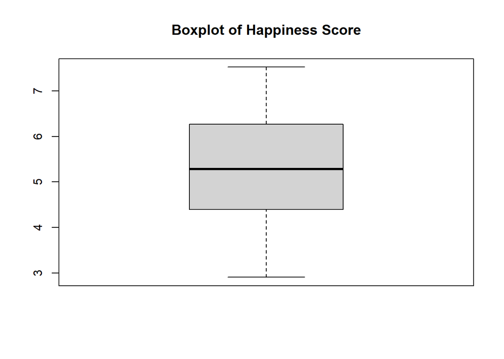

```r
#Creamos boxplots de la variable HS
boxplot(happiness$HS, main="Boxplot of Happiness Score")
```

```r
boxplot.stats(happiness$HS)
```

```
## $stats
## [1] 2.905 4.395 5.285 6.269 7.526
##
## $n
## [1] 142
##
## $conf
## [1] 5.036525 5.533475
##
## $out
## numeric(0)
```

```r
summary(happiness$HS)
```

```
##    Min. 1st Qu.  Median    Mean 3rd Qu.    Max.    NA's
##   2.905   4.397   5.285   5.365   6.261   7.526      15
```

En la variable HS, no existen outliers.

### Government Corruption (GC)

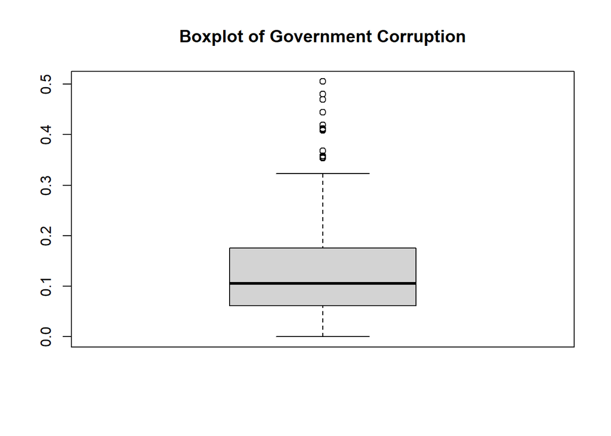

```r
#Creamos boxplots de la variable GC
boxplot(happiness$GC, main="Boxplot of Government Corruption")
```

```r
#Vemos los valores importantes del boxplot
boxplot.stats(happiness$GC)
```

```
## $stats
## [1] 0.00000 0.06126 0.10547 0.17554 0.32331
##
## $n
## [1] 157
##
## $conf
## [1] 0.09105955 0.11988045
##
## $out
##  [1] 0.44453 0.41203 0.35776 0.41004 0.41904 0.40867 0.35329 0.46987 0.35561
## [10] 0.48049 0.36794 0.50521
```

```r
#Vemos las estadísticas más importantes para complementar los valores anteriores.
summary(happiness$GC)
```

```
##    Min. 1st Qu.  Median    Mean 3rd Qu.    Max.
## 0.00000 0.06126 0.10547 0.13762 0.17554 0.50521
```

En la variable GC, existen 12 outliers. No está claro si estos valores atípicos también son anómalos debido a que no sabemos el rango de valores permitidos al medir la variable “Government.Corruption”. Si el rango de valores permitidos es de 0 a 1, entonces los valores atípicos NO son anómalos. Sin embargo, si el rango de valores de la variable va de 0 a 0.5, entonces si existe un valor anómalo: 0.50521.

```r
happiness[happiness$GC > 0.32331, c("Country", "GC")]
```

```
##                  Country      GC
## 1                Denmark 0.44453
## 2            Switzerland 0.41203
## 4                 Norway 0.35776
## 5                Finland 0.41004
## 8            New Zealand 0.41904
## 10                Sweden 0.40867
## 20            Luxembourg 0.35329
## 22             Singapore 0.46987
## 28  United Arab Emirates 0.35561
## 36                 Qatar 0.48049
## 97     Somaliland Region 0.36794
## 152               Rwanda 0.50521
```

Podemos observar los países de los valores atípicos. El único posible valor anómalo pertenece a Rwanda. Sin embargo, decidimos mantenerlo y considerarlo como atípico pero no anómalo, porque no tenemos la información necesaria.

### Generosity

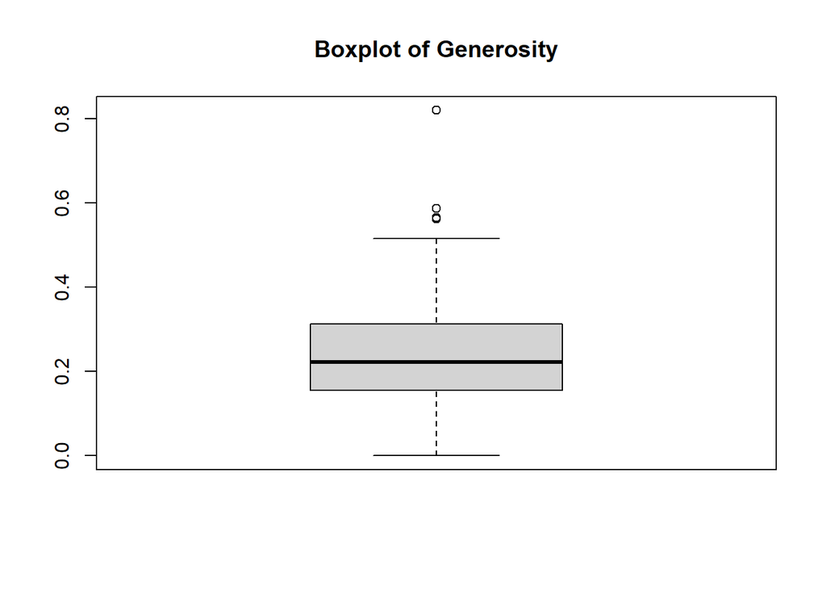

```r
#Creamos boxplots de la variable Generosity
boxplot(happiness$Generosity, main="Boxplot of Generosity")
```

```r
boxplot.stats(happiness$Generosity)
```

```
## $stats
## [1] 0.00000 0.15457 0.22245 0.31185 0.51479
##
## $n
## [1] 157
##
## $conf
## [1] 0.2026173 0.2422827
##
## $out
## [1] 0.56237 0.58696 0.56521 0.81971
```

```r
summary(happiness$Generosity)
```

```
##    Min. 1st Qu.  Median    Mean 3rd Qu.    Max.
##  0.0000  0.1546  0.2225  0.2426  0.3119  0.8197
```

Según el boxplot de la variable Generosity, existen 4 valores atípicos.El valor máximo del boxplot, el bigote superior, es 0.51479. Tres de los valores atípicos están alrededor de 0.5, excepto un valor de 0.81971. Así que procedemos a revisar estos valores.

```r
happiness[happiness$Generosity > 0.51479, c("Country", "Generosity")]
```

```
##       Country Generosity
## 30      Malta    0.56237
## 33   Thailand    0.58696
## 79  Indonesia    0.56521
## 119   Myanmar    0.81971
```

El valor atípico de 0.81971 de la variable Generosity pertence al país de Myanmar. Si el rango de valores para esta variable está entre 0 y 1, entonces este sería atípico, pero no anómalo. Necesitamos más información sobre el dataset y la variable para determinar si este es un valor anómalo.

### Family

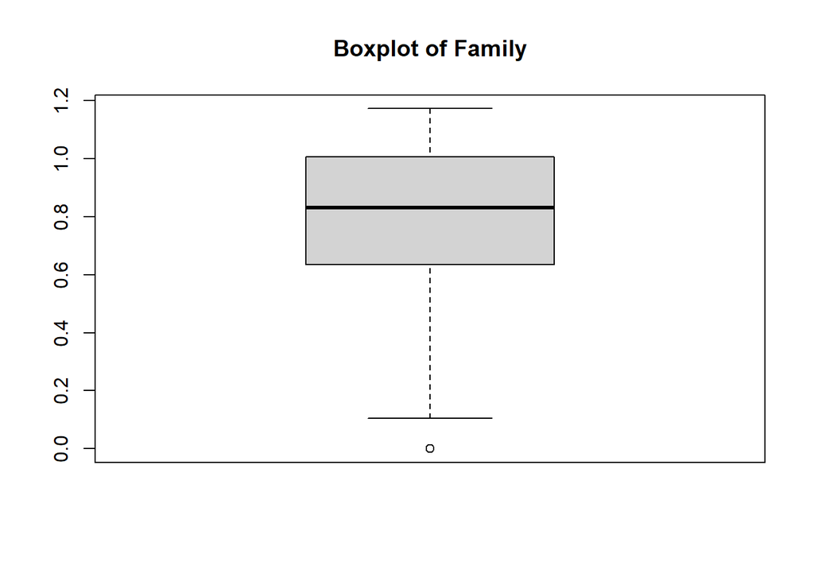

```r
#Creamos boxplots de la variable Family
boxplot(happiness$Family, main="Boxplot of Family")
```

```r
# Revisamos los valores del boxplot
boxplot.stats(happiness$Family)
```

```
## $stats
## [1] 0.104190 0.634690 0.832205 1.006505 1.172780
##
## $n
## [1] 152
##
## $conf
## [1] 0.7845551 0.8798549
##
## $out
## [1] 0
```

```r
# Complementamos los datos anteriores con el del resumen estadístico.
summary(happiness$Family)
```

```
##    Min. 1st Qu.  Median    Mean 3rd Qu.    Max.    NA's
##  0.0000  0.6361  0.8322  0.7854  1.0058  1.1728       5
```

Según el boxplot de la variable Family, existe un valor atípico de 0. Así que lo revisamos a continuación.

```r
#Obtenemos la fila con el valor 0 en la variable Family, ignorando los NAs.
happiness[complete.cases(happiness$Family) & happiness$Family==0, c("Country", "Family" )]
```

```
##     Country Family
## 155    Togo      0
```

Togo es el único país que tiene el valor de 0 en la variable Family, y el boxplot lo cataloga como valor atípico. Por lo tanto, decidimos que en efecto este es un valor atípico y anómalo, por lo que lo convertimos en NA.

```r
# Sustituimos el valor atípico y anómalo de la variable Family por un NA.
happiness[complete.cases(happiness$Family) & happiness$Family==0, "Family"] <- NA

# Observamos el nuevo valor de Family para el país de Togo.
happiness[happiness$Country == "Togo", c("Country", "Family")]
```

```
##     Country Family
## 155    Togo     NA
```

# 6. Imputación de valores

```r
str(happiness)
```

```
## 'data.frame':    157 obs. of  12 variables:
##  $ Country   : chr  "Denmark" "Switzerland" "Iceland" "Norway" ...
##  $ Region    : chr  "Western Europe" "Western Europe" "Western Europe" "Western Europe" ...
##  $ HR        : num  1 NA 2 3 4 5 6 7 NA 8 ...
##  $ HS        : num  7.53 NA 7.5 7.5 7.41 ...
##  $ LCI       : num  7.46 7.43 7.33 7.42 7.35 ...
##  $ UCI       : num  7.59 7.59 7.67 7.58 7.47 ...
##  $ GpC       : num  1.44 1.53 1.43 1.58 1.41 ...
##  $ Family    : num  1.16 1.15 NA 1.13 1.13 ...
##  $ LE        : num  0.795 0.863 0.867 0.796 0.811 ...
##  $ Freedom   : num  0.579 0.586 0.566 0.596 0.571 ...
##  $ GC        : num  0.445 0.412 0.15 0.358 0.41 ...
##  $ Generosity: num  0.362 0.281 0.477 0.379 0.255 ...
```

```r
# Observamos las variable numéricas del dataset que contienen algunos valores nulos
head(happiness[, c("HS", "LCI", "UCI", "GpC", "Family", "LE", "Freedom", "GC", "Generosity")])
```

```
##      HS   LCI   UCI     GpC  Family      LE Freedom      GC Generosity
## 1 7.526 7.460 7.592 1.44178 1.16374 0.79504 0.57941 0.44453    0.36171
## 2    NA 7.428 7.590 1.52733 1.14524 0.86303 0.58557 0.41203    0.28083
## 3 7.501 7.333 7.669 1.42666      NA 0.86733 0.56624 0.14975    0.47678
## 4 7.498 7.421 7.575 1.57744 1.12690 0.79579 0.59609 0.35776    0.37895
## 5 7.413 7.351 7.475 1.40598 1.13464 0.81091 0.57104 0.41004    0.25492
## 6 7.404 7.335 7.473 1.44015 1.09610 0.82760 0.57370 0.31329    0.44834
```

```r
# Obtenemos el numero de valores nulos por variable.
colSums(is.na(happiness[, c("HS", "LCI", "UCI", "GpC", "Family", "LE", "Freedom", "GC", "Generosity")]))
```

```
##         HS        LCI        UCI        GpC     Family         LE    Freedom
##         15          0          0          0          6          0          0
##         GC Generosity
##          0          0
```

```r
# Observamos los países que tienen valores NA en las variables numéricas.
happiness[is.na(happiness$HS) | is.na(happiness$Family), c("Country", "HS", "Family")]
```

```
##            Country    HS  Family
## 2      Switzerland    NA 1.14524
## 3          Iceland 7.501      NA
## 7      Netherlands 7.339      NA
## 9        Australia    NA 1.10476
## 27  Czech Republic    NA 1.00793
## 30           Malta 6.488      NA
## 35          Taiwan    NA 0.92624
## 36           Qatar 6.375      NA
## 44       Venezuela    NA      NA
## 48       Nicaragua    NA 0.89521
## 52          Belize    NA 0.68655
## 59         Bolivia    NA 0.83779
## 61         Belarus    NA 1.04993
## 72         Estonia    NA 1.05163
## 114       Cameroon    NA 0.62542
## 117      Sri Lanka    NA 0.84783
## 121        Armenia    NA 0.62477
## 140       Cambodia    NA 0.53750
## 155           Togo 3.303      NA
## 156          Syria    NA 0.14866
```

Vemos que la variable HS tiene 15 valores nulos, Family tiene 6 valores nulos y las demás variables tienen 0 valores nulos.

```r
# Imputamos en los valores nulos los resultados de aplicar la funcion kNN.
happiness[, c("HS", "LCI", "UCI", "GpC", "Family", "LE", "Freedom", "GC", "Generosity")] <- kNN(happiness[, c("HS", "LCI", "UCI", "GpC", "Family", "LE", "Freedom", "GC", "Generosity")], k = 11)
# Observamos el dataset actualizado con los datos imputados
head(happiness[, c("HS", "LCI", "UCI", "GpC", "Family", "LE", "Freedom", "GC", "Generosity")])
```

```
##      HS   LCI   UCI     GpC  Family      LE Freedom      GC Generosity
## 1 7.526 7.460 7.592 1.44178 1.16374 0.79504 0.57941 0.44453    0.36171
## 2 7.291 7.428 7.590 1.52733 1.14524 0.86303 0.58557 0.41203    0.28083
## 3 7.501 7.333 7.669 1.42666 1.09774 0.86733 0.56624 0.14975    0.47678
## 4 7.498 7.421 7.575 1.57744 1.12690 0.79579 0.59609 0.35776    0.37895
## 5 7.413 7.351 7.475 1.40598 1.13464 0.81091 0.57104 0.41004    0.25492
## 6 7.404 7.335 7.473 1.44015 1.09610 0.82760 0.57370 0.31329    0.44834
```

```r
# Contamos de nuevo los valores nulos de cada variable numérica
colSums(is.na(happiness[, c("HS", "LCI", "UCI", "GpC", "Family", "LE", "Freedom", "GC", "Generosity")]))
```

```
##         HS        LCI        UCI        GpC     Family         LE    Freedom
##          0          0          0          0          0          0          0
##         GC Generosity
##          0          0
```

El resultado es que cada columna ya no tiene valores NAs.

Como todos los valores NA han sido imputados, incluido los NA de la variable HS, ahora si podemos crear una secuencia de números en la variable HR que representen los valores de HS.

```r
# Colocamos NA en toda la columna HR
happiness$HR <- NA_integer_

#Obtenemos la posición/orden de los valores de la variable HS
rank_HS2 <- rank(happiness$HS, ties.method="first")

#Invertimos los valores de las posiciones/orden para que el mayor sea el primero y viceversa
reversed_rank_HS2 <- length(happiness$HS) + 1 - rank_HS2

#Colocamos los valores de las posiciones en la variable HR
happiness[, "HR"] <- reversed_rank_HS2

#Imprimimos para visualizar
head(happiness[, c("Country", "HR", "HS")], 10)
```

```
##        Country HR    HS
## 1      Denmark  1 7.526
## 2  Switzerland 10 7.291
## 3      Iceland  2 7.501
## 4       Norway  3 7.498
## 5      Finland  4 7.413
## 6       Canada  5 7.404
## 7  Netherlands  6 7.339
## 8  New Zealand  7 7.334
## 9    Australia  9 7.291
## 10      Sweden  8 7.291
```

Como vemos, después de que los valores NAs de HS han sido imputados basados en kNN, ponemos los valores adecuados para HR basados en los nuevos valores de HS. Por ejemplo, Switzerland, Australia and Sweden tienen el mismo valor de 7.291 en HS, por lo que ocupan las posiciones 8, 9 y 10. Cuando anteriormente Switzerland no tenía ningún valor en HS, por lo tanto habíamos puesto NA tambien en su correspondiente valor de HR.

```r
str(happiness)
```

```
## 'data.frame':    157 obs. of  12 variables:
##  $ Country   : chr  "Denmark" "Switzerland" "Iceland" "Norway" ...
##  $ Region    : chr  "Western Europe" "Western Europe" "Western Europe" "Western Europe" ...
##  $ HR        : num  1 10 2 3 4 5 6 7 9 8 ...
##  $ HS        : num  7.53 7.29 7.5 7.5 7.41 ...
##  $ LCI       : num  7.46 7.43 7.33 7.42 7.35 ...
##  $ UCI       : num  7.59 7.59 7.67 7.58 7.47 ...
##  $ GpC       : num  1.44 1.53 1.43 1.58 1.41 ...
##  $ Family    : num  1.16 1.15 1.1 1.13 1.13 ...
##  $ LE        : num  0.795 0.863 0.867 0.796 0.811 ...
##  $ Freedom   : num  0.579 0.586 0.566 0.596 0.571 ...
##  $ GC        : num  0.445 0.412 0.15 0.358 0.41 ...
##  $ Generosity: num  0.362 0.281 0.477 0.379 0.255 ...
```

# 7. Estudio descriptivo

## 7.1. Representación gráfica de variables

```r
# Obtenemos la media de cada Region
df_Region_Freedom <- happiness[, c("Region", "Freedom")] %>% group_by(Region) %>% summarize(mean_freedom=mean(Freedom))

df_Region_Freedom <- df_Region_Freedom[order(df_Region_Freedom$mean_freedom),]

df_Region_Freedom
```

```
## # A tibble: 10 × 2
##    Region                          mean_freedom
##    <chr>                                  <dbl>
##  1 Central and Eastern Europe             0.301
##  2 Middle East and Northern Africa        0.310
##  3 Sub-Saharan Africa                     0.315
##  4 Southern Asia                          0.350
##  5 Eastern Asia                           0.387
##  6 Latin America and Caribbean            0.427
##  7 Western Europe                         0.478
##  8 Southeastern Asia                      0.490
##  9 North America                          0.528
## 10 Australia and New Zealand              0.575
```

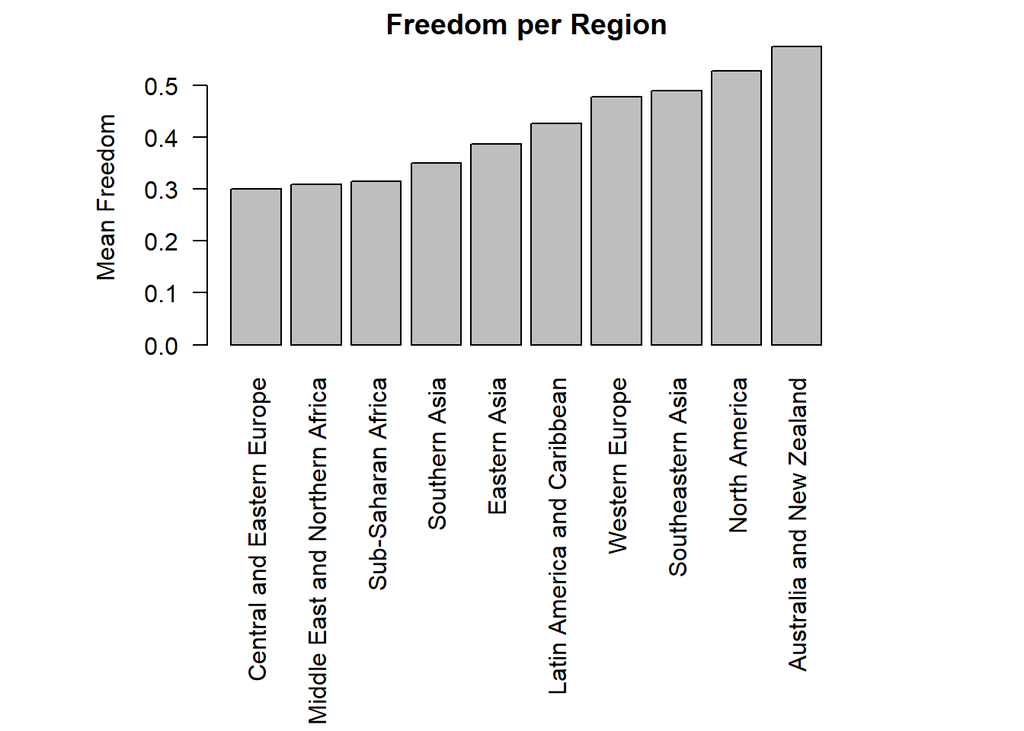

```r
# Establecemos las medidas de los margenes del barplot.
par(mar=c(13, 7, 1.5, 6) + 0.1)

# Creamos el barplot
barplot(df_Region_Freedom$mean_freedom, names.arg=df_Region_Freedom$Region, ylab="Mean Freedom", main="Freedom per Region", las=2)
```

## 7.2. Medidas características

```r
# Obtenemos las medidas de tendencia central robustas y no robustas

#MEAN
happiness_mean <- colMeans(happiness[, c("HS", "LCI", "UCI", "GpC", "Family", "LE", "Freedom", "GC", "Generosity")])

#MEDIAN
happiness_median <- apply(happiness[, c("HS", "LCI", "UCI", "GpC", "Family", "LE", "Freedom", "GC", "Generosity")], 2, median)

#TRIMMED MEAN
happiness_trimmed_mean <- apply(happiness[, c("HS", "LCI", "UCI", "GpC", "Family", "LE", "Freedom", "GC", "Generosity")], 2,function(x) median(x, trim=0.05))

#apply(happiness[, c("HS", "LCI", "UCI", "GpC", "Family", "LE", "Freedom", "GC", "Generosity")], 2, function(x) winsor.mean(x, trim=0.05))

# Creamos un dataframe con las medidas de tendencia central para cada variable.
df_central_tendency <- data.frame(mean=happiness_mean, median=happiness_median, trimmed_mean=happiness_trimmed_mean)
```

```r
# Creamos una tabla con las medidas de tendencia central para cada variable.
kable(df_central_tendency)
```

|  | mean | median | trimmed_mean |
| --- | --- | --- | --- |
| HS | 5.3896051 | 5.31400 | 5.31400 |
| LCI | 5.2975414 | 5.26700 | 5.26700 |
| UCI | 5.4819745 | 5.41900 | 5.41900 |
| GpC | 0.9538798 | 1.02780 | 1.02780 |
| Family | 0.7969679 | 0.84142 | 0.84142 |
| LE | 0.5576190 | 0.59659 | 0.59659 |
| Freedom | 0.3709939 | 0.39747 | 0.39747 |
| GC | 0.1376238 | 0.10547 | 0.10547 |
| Generosity | 0.2426349 | 0.22245 | 0.22245 |

```r
# Obtenemos las medidas de dispersión de las variables numéricas

#STANDARD DEVIATION
happiness_sd <- apply(happiness[, c("HS", "LCI", "UCI", "GpC", "Family", "LE", "Freedom", "GC", "Generosity")], 2, sd)

#INTER-QUANTILE RANGE
happiness_IQR <- apply(happiness[, c("HS", "LCI", "UCI", "GpC", "Family", "LE", "Freedom", "GC", "Generosity")], 2, IQR)

#MEDIAN ABSOLUTE DEVIATION - Desviación absoluta respecto de la mediana (DAM)
happiness_DAM <- apply(happiness[, c("HS", "LCI", "UCI", "GpC", "Family", "LE", "Freedom", "GC", "Generosity")], 2, mad)

#Creamos un dataframe con las medidas de dispersión.
df_dispersion <- data.frame(desviacion_estandar=happiness_sd, rango_intercuartilico=happiness_IQR, desviacion_absoluta=happiness_DAM )

#Creamos una tabla con el dataframe recién creado.
kable(df_dispersion)
```

|  | desviacion_estandar | rango_intercuartilico | desviacion_absoluta |
| --- | --- | --- | --- |
| HS | 1.1207139 | 1.86500 | 1.3714050 |
| LCI | 1.1480398 | 1.79800 | 1.3373052 |
| UCI | 1.1364932 | 1.96900 | 1.4262612 |
| GpC | 0.4125954 | 0.60940 | 0.4327561 |
| Family | 0.2597438 | 0.37968 | 0.2912419 |
| LE | 0.2293492 | 0.34702 | 0.2478462 |
| Freedom | 0.1455068 | 0.22705 | 0.1662588 |
| GC | 0.1110379 | 0.11428 | 0.0792301 |
| Generosity | 0.1337557 | 0.15728 | 0.1156725 |

# 8. Archivo final

Una vez realizado el preprocesamiento sobre el archivo, guardar el resultado de los datos en un archivo llamado Happiness_clean.csv.

```r
write.csv(happiness, "Happiness_clean.csv", row.names=FALSE)
```

# 9. Informe Ejecutivo

## 9.1. Presentación de los principales resultados del estudio en una tabla

[output not shown]

## 9.2 Resumen estadístico

Incluir una breve explicación de las características estadísticas básicas de cada variable por separado

```r
summary(happiness)
```

```
##    Country             Region                HR            HS
##  Length:157         Length:157         Min.   :  1   Min.   :2.905
##  Class :character   Class :character   1st Qu.: 40   1st Qu.:4.404
##  Mode  :character   Mode  :character   Median : 79   Median :5.314
##                                        Mean   : 79   Mean   :5.390
##                                        3rd Qu.:118   3rd Qu.:6.269
##                                        Max.   :157   Max.   :7.526
##       LCI             UCI             GpC             Family
##  Min.   :2.732   Min.   :3.078   Min.   :0.0000   Min.   :0.1042
##  1st Qu.:4.371   1st Qu.:4.465   1st Qu.:0.6702   1st Qu.:0.6418
##  Median :5.267   Median :5.419   Median :1.0278   Median :0.8414
##  Mean   :5.298   Mean   :5.482   Mean   :0.9539   Mean   :0.7970
##  3rd Qu.:6.169   3rd Qu.:6.434   3rd Qu.:1.2796   3rd Qu.:1.0215
##  Max.   :7.460   Max.   :7.669   Max.   :1.8243   Max.   :1.1728
##        LE            Freedom             GC            Generosity
##  Min.   :0.0000   Min.   :0.0000   Min.   :0.00000   Min.   :0.0000
##  1st Qu.:0.3829   1st Qu.:0.2575   1st Qu.:0.06126   1st Qu.:0.1546
##  Median :0.5966   Median :0.3975   Median :0.10547   Median :0.2225
##  Mean   :0.5576   Mean   :0.3710   Mean   :0.13762   Mean   :0.2426
##  3rd Qu.:0.7299   3rd Qu.:0.4845   3rd Qu.:0.17554   3rd Qu.:0.3119
##  Max.   :0.9528   Max.   :0.6085   Max.   :0.50521   Max.   :0.8197
```

#### Happiness.Score (HS)

En un rango del 1 al 10 que representa el puntaje de felicidad de cada país, podemos ver que el valor mínimo es 2.905 y el máximo es 7.526, mientras que la media y mediana de todos los países son casi las mismas con el valor de 5.3.

#### Upper.Confidence.Interval (UCI)

El intervalo de confianza más alto contiene los valores probables representativos de las población del puntaje de felicidad. Así que estos son mayores que HS. Así, el valor mínimo es 3.078, el valor máximo es 7.669, la media es 5.482 y la mediana es 5.419.

#### GDP.per.Capita (GpC)

El valor de GpC es difícil de interpretar, porque no sabemos la unidad de medida que se utiliza en el dataset. Como vemos el rango va de 0 a 1.82.

#### Family

Esta variable representa el número de amigos y familiares con los que una persona puede contar. El valor mínimo de uno de los países en el dataset es de 0.1042, el valor máximo es 1.1728, la media es 0.7970 y la mediana 0.8414. Son valores bajos, mostrando poco capital social en los diferentes países.

#### Life.Expectancy (LE)

Esta variable está en un rango de 0 a 1, por lo que también es difícil de interpretar. Si los valores fueran absolutos en vez de relativos serían más comprensible. Sin embargo, el valor mínimo es 0, el máximo es 0.9528, la media es 0.5576 y la mediana es 0.5966.

#### Freedom

Suponemos que esta variable tiene un rango de 0 a 10, sin embargo no tenemos la información precisa. El valor mínimo es 0, el máximo es 0.6085, la media 0.3710 y la mediana es 0.3975. Lo cual muestra bajos valores de libertad en la mayoría de países.

#### Generosity

La generosidad parece que se mide de 0 a 10. Siendo el valor mínimo 0, el máximo 0.8197, la media 0.2426 y la mediana 0.2225. Esto nos indica que un valor alto en la variable Generosity es bastante raro, la mayoría son valores bajos.